# R Notebook

```r
class(AirPassengers)
```

```
[1] "ts"
```

Check the data is Stationary or not?

Properties of data to be stationary a. Mean is constant. b. Variance is constant(equi distance from mean). c. Covariances are same.

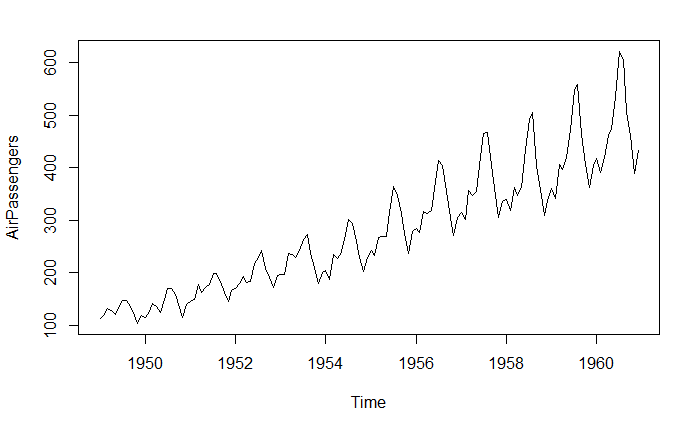

Plot the graph and then mean/ abline

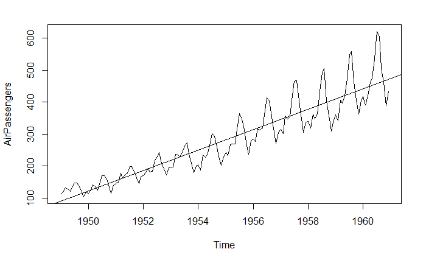

```r
plot(AirPassengers)
abline(reg = lm(AirPassengers~time(AirPassengers)))
```

Check the trend Component

[figure not shown]

```r
cycle(AirPassengers)
```

```
     Jan Feb Mar Apr May Jun Jul Aug Sep Oct Nov Dec
1949   1   2   3   4   5   6   7   8   9  10  11  12
1950   1   2   3   4   5   6   7   8   9  10  11  12
1951   1   2   3   4   5   6   7   8   9  10  11  12
1952   1   2   3   4   5   6   7   8   9  10  11  12
1953   1   2   3   4   5   6   7   8   9  10  11  12
1954   1   2   3   4   5   6   7   8   9  10  11  12
1955   1   2   3   4   5   6   7   8   9  10  11  12
1956   1   2   3   4   5   6   7   8   9  10  11  12
1957   1   2   3   4   5   6   7   8   9  10  11  12
1958   1   2   3   4   5   6   7   8   9  10  11  12
1959   1   2   3   4   5   6   7   8   9  10  11  12
1960   1   2   3   4   5   6   7   8   9  10  11  12
```

Seasonalty Component

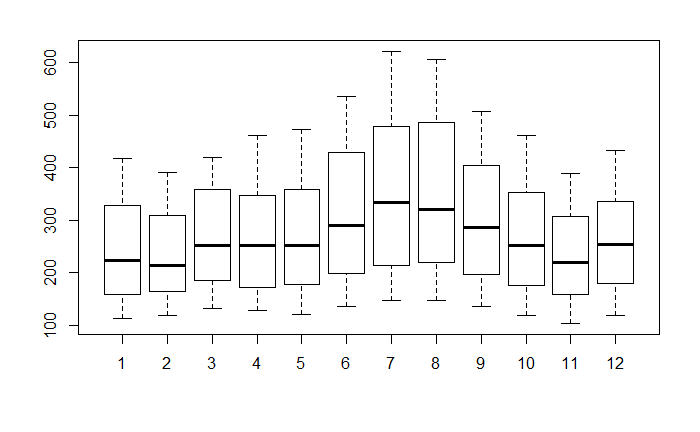

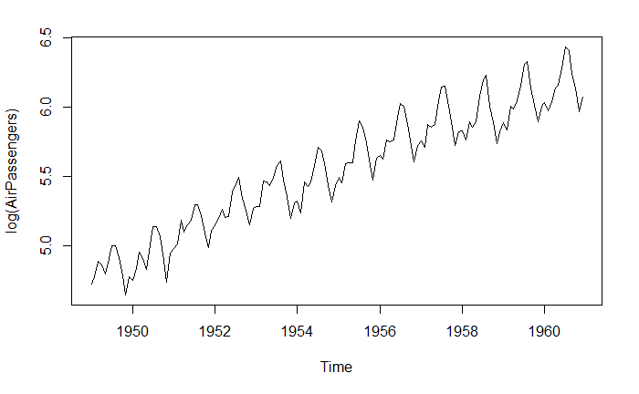

```r
plot(log(AirPassengers))
```

2. Use diff. this helps to sort the first property that mean is constant

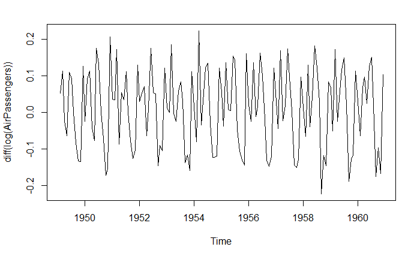

Model ARIMA - Autoregressive Integration Moving Average There are values associated with ARIMA Autoregressive - p Integration - d Moving Average - q

we get these values from acf graph.

Step1 : check untransformed data

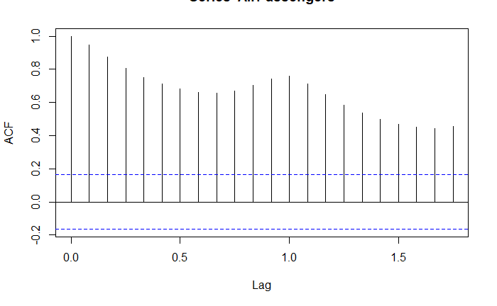

Step 2: Calculate the value of p,d,q

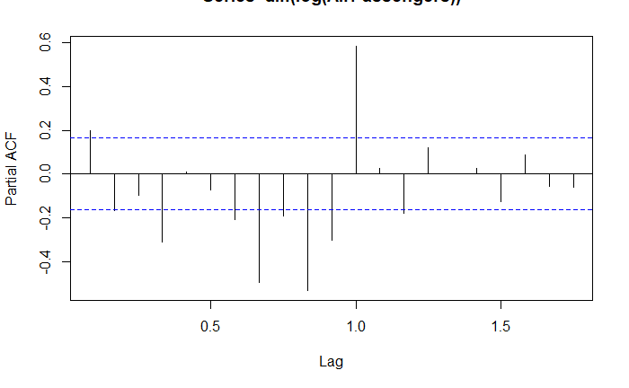

Step 3 Apply values to ARIMA Model

```r
fit = arima(log(AirPassengers), c(0,1,1), seasonal = list(order = c(0,1,1), period = 12))
```

Predict for next 10 years

```r
pred = predict(fit, n.ahead = 10*12)
```

The values are in log form so to convert use 2.718^values

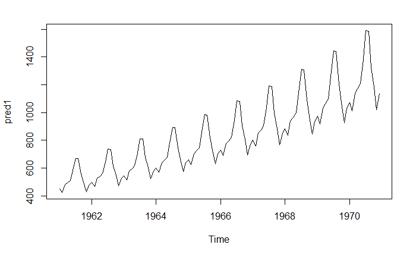

Forecated plot

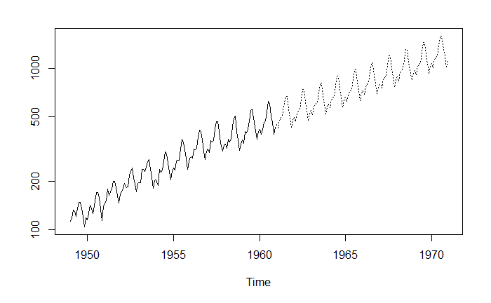

step 5: Test the model break the data into train, test and then test the model train dataset = 1949 to 1959 test dataset = 1960

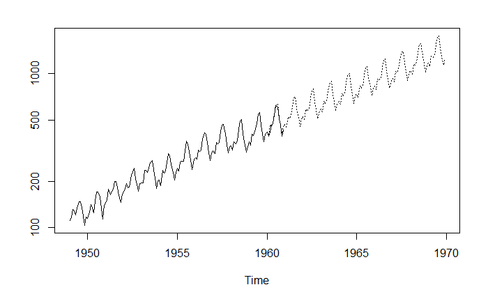

```r
df_train = ts(AirPassengers, frequency = 12, start = c(1949,1), end = c(1959, 12))
fit2 = arima(log(df_train), c(0,1,1), seasonal = list(order= c(0,1,1), period = 12))
test_log = predict(fit2, n.ahead = 10*12)
test_values = 2.718^test_log$pred
ts.plot(AirPassengers, test_values, log = "y", lty = c(1,3))
```

Check 1960

```r
data_1960 = head(test_values, 12)
data_1960 = round(data_1960, digit=0)
data_1960
```

```
 [1] 419 399 466 454 473 547 622 630 526 462 406 452
```

```r
original_1960 = tail(AirPassengers, 12)
original_1960
```

```
 [1] 417 391 419 461 472 535 622 606 508 461 390 432
```